# BR PS 2

AP

9/23/2021

## Exercise 2.1

### Part A

posterior > prior

### Part B

prior > posterior

### Part C

posterior > prior

### Part D

posterior > prior (nobody likes too many hashtags)

## Exercise 2.2

### Part A

$$P (\text{B} | \text{A}) = \text{.73}$$

### Part B

$$P (\text{A}) = \text{.2}$$

### Part C

$$P (\text{D}) = \text{.15}$$

### Part D

$$P (\text{D} | \text{C}) = \text{.91}$$

### Part E

$$P (\text{E} \cap \text{F}) = \text{.38}$$

### Part F

$$P (\text{E} | \text{F}) = \text{.95}$$

## Exercise 2.3

### Part A

This isn’t a binomial probability; there’s not a fixed number of trials OR only two possible outcomes (there are infinite possible outcomes, as theoretically ANY amount of babies could be born between 9 and 10am tomorrow).

### Part B

Yes! Y is binomial, because there’s a fixed number of trials (27 planted tulips) and only two possible outcomes (blooms or doesn’t).
$$f(y|\pi = .9) = \binom{27}{y} .9^{y} (1-.9)^{27-y} \text{ for } y \in \{1, 2, 3, ... 27\}$$

### Part C

Yes, you can model this using a binomial probability, except instead of the number of *successes* being unknown, the number of *trials* is unknown.
$$f(y|\pi = .17|k = 1) = \binom{y}{1} .17^{1} (1-.17)^{y-1}$$

### Part D

This is not a binomial, because there are more outcomes than simply success or failure (there are infinitely many outcomes, because he could be infinitely many minutes late).

### Part E

This isn’t a binomial probability either…I’m not sure why to be completely honest, it’s just a gut feeling.

### Part F

This one is a binomial probability!
$$f(y|\pi = .8) = \binom{60}{y} .8^{y} (1-.8)^{60-y} \text{ for } y \in \{1, 2, 3, ... 60\}$$

## Exercise 2.4

post odds = prior odds * likelihood ratio

prior odds = 5/95 = 1/19

likelihood ratio = .7 / .03 = 23.333

post odds = (1/19) * 23.333 = 23.333 / 19

post probability = 23.333 / (19 + 23.333) = .551 = 55.1%

## Exercise 2.5

### Part A

$$P(\text{mold}) = .18 = 18\%$$

### Part B

$$P(\text{maple}) = P(\text{maple} \cap \text{diseased}) + P(\text{maple} \cap \text{healthy}) = (.18)(.80) + (.82)(.10) = .226 = 22.6\%$$

### Part C

prior odds = .18/.82 = 9/41

likelihood ratio = .80/.10 = 8

post odds = 9/41 * 8 = 72/41

post probability = 72/(41+72) = .637 = 63.7%

### Part D

The posterior probability is higher than the prior, which makes sense since the majority of infected trees were maples and only a small percentage of the healthy trees were maples, so intuitively it’s more likely that a maple tree is diseased than healthy. However, it also makes sense that the post probability isn’t *extremely* high, because a low percentage of the trees in the orchard are actually diseased.

## Exercise 2.6

We need to know the percentage of restaurants that Sandra *doesn’t* like that have fewer than 4 stars on Yelp.

## Exercise 2.7

### Part A

$$P(\text{non-binary}) = P(\text{swipe right} \cap \text{non-binary}) + P(\text{swipe left} \cap \text{nonbinary}) = (.08)(.20) + (.92)(.10) = .108 = 10.8\%$$

### Part B

prior odds = .08/.92 = 2/23

likelihood ratio = .20/.10 = 2

post odds = 2/23 * 2 = 4/23

post probability = 4/(4+23) = .148 = 14.8%

## Exercise 2.8

### Part A

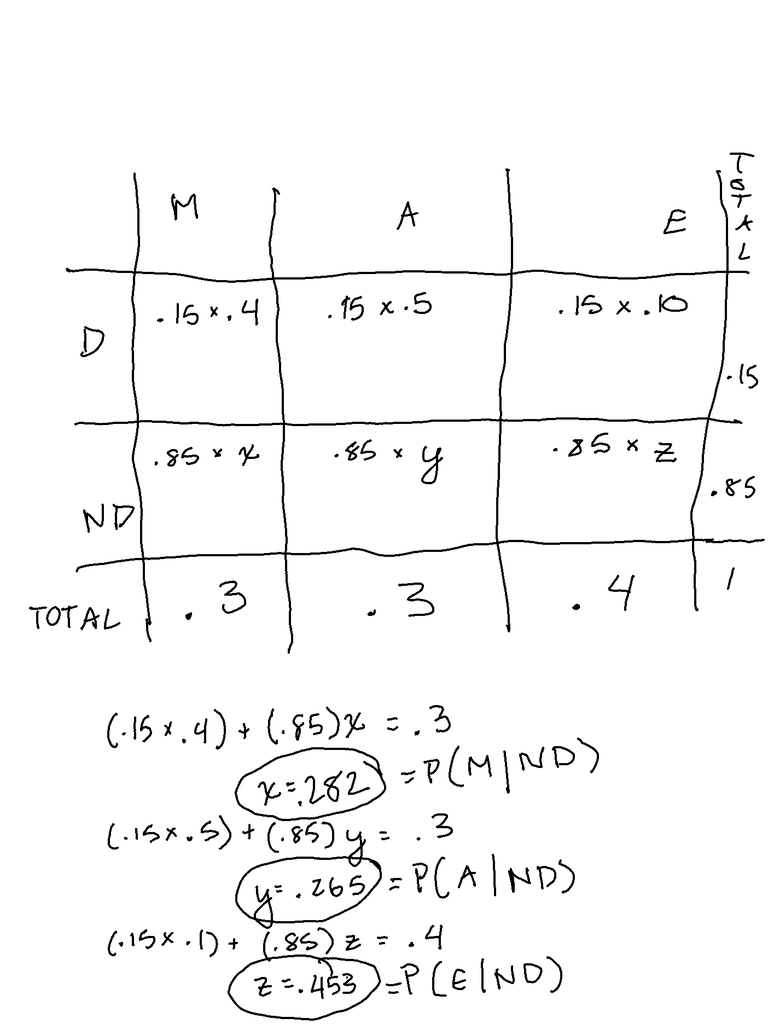

prior odds = .15/.85 = 3/17

likelihood ratio = .4/.282 = 1.42

post odds = 3/17 * 1.42 = .25

post probability = .25 / (1 + .25) = .2 = 20%

### Part B

28.2% (see above image for explanation of work)

## Exercise 2.9

### Part A

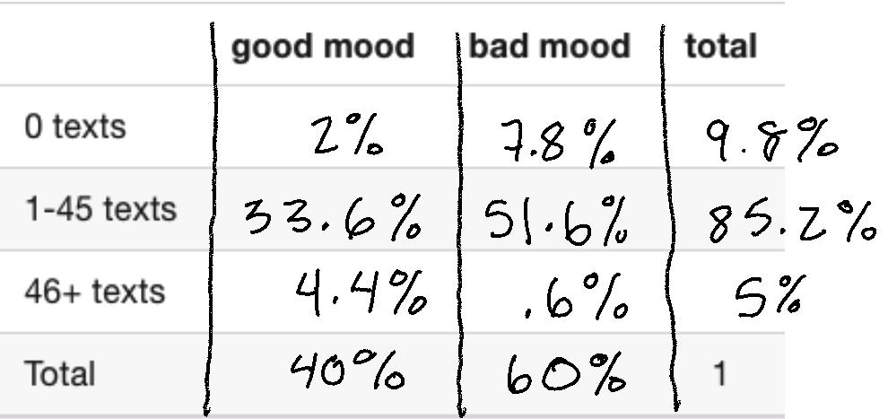

image 2.9

### Part B

The probability would be 40%; this is the prior.

### Part C

4.4%; this is the likelihood.

### Part D

4.4/5, or 88%.

## Exercise 2.10

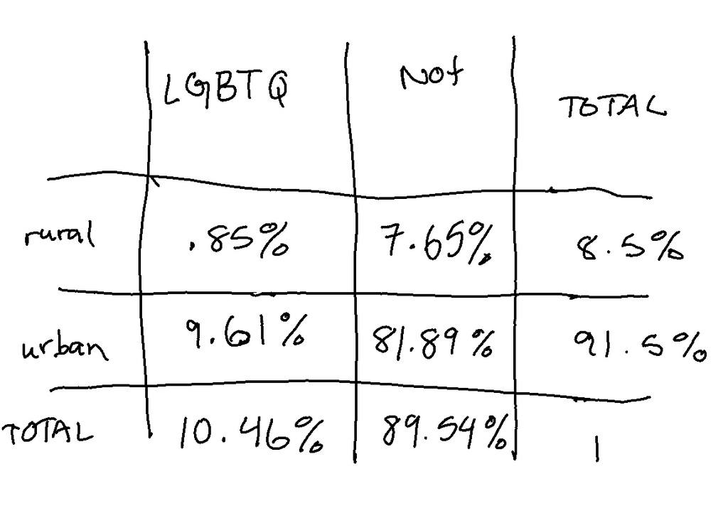

image 2.10

### Part A

10.46%

### Part B

9.61/10.46 = 91.87%

### Part C

7.65/89.54 = 8.54%

## Exercise 2.11

### Part A

$$f(y|\pi) = \binom{6}{y} \pi^{y} (1-\pi)^{6-y} \text{ for } y \in \{1, 2, 3, ... 6\}$$

### Part B

```r
choose(6,4)*(.3^4)*(.7^2)
```

```
## [1] 0.059535
```

The probability would be .0595, or 5.95%.

### Part C

```r
pi <- c(.3,.4,.5)
prior <- c(.25, .6, .15)
likelihood <- choose(6,4)*(pi^4)*((1-pi)^2)
normconstant <- sum(likelihood*prior)
posterior <- prior * likelihood / normconstant
data.frame(pi, posterior)
```

```
##    pi posterior
## 1 0.3 0.1119214
## 2 0.4 0.6237141
## 3 0.5 0.2643645
```

## Exercise 2.12

### Part A

$$f(y|\pi) = \binom{7}{y} \pi^{y} (1-\pi)^{7-y} \text{ for } y \in \{1, 2, 3, ... 7\}$$

### Part B

$$f(\pi|y = 1) = 7\pi(1-\pi)^{6}$$

The updated model would be as follows:

```r
pi2 <- c(.1,.25,.4)
prior2 <- c(.2, .45, .35)
likelihood2 <- 7*(pi2)*((1-pi2)^6)
normconstant2 <- sum(likelihood2*prior2)
posterior2 <- prior2 * likelihood2 / normconstant2
data.frame(pi2, posterior2)
```

```
##    pi2 posterior2
## 1 0.10  0.2858497
## 2 0.25  0.5384840
## 3 0.40  0.1756662
```

### Part C

The posterior model seems to be leaning towards lower values of pi than the prior, which makes sense since the data point we factored in was that he only made 1 of 7 good handles, so we would expect him to be a worse ceramics guy than we thought before.

### Part D

Kris’s updated model is as follows:

```r
pi3 <- c(.1,.25,.4)
prior3 <- c(.15, .15, .7)
likelihood3 <- 7*(pi3)*((1-pi3)^6)
normconstant3 <- sum(likelihood3*prior3)
posterior3 <- prior3 * likelihood3 / normconstant3
data.frame(pi3, posterior3)
```

```
##    pi3 posterior3
## 1 0.10  0.2876854
## 2 0.25  0.2408631
## 3 0.40  0.4714515
```

## Exercise 2.13

### Part A

My first guess is that the .6 probability will be slightly higher, and the others will be slightly lower, since 47/80 is closest to .6. However, I don’t expect any major changes.

### Part B

```r
pi4 <- c(.4, .5, .6, .7)
prior4 <- c(.1, .2, .44, .26)
likelihood4 <- choose(80,47)*(pi4^47)*((1-pi4)^33)
normconstant4 <- sum(likelihood4*prior4)
posterior4 <- prior4 * likelihood4 / normconstant4
data.frame(pi4, posterior4)
```

```
##   pi4   posterior4
## 1 0.4 0.0006491288
## 2 0.5 0.1135403807
## 3 0.6 0.8337986003
## 4 0.7 0.0520118903
```

There was definitely more of a change in the posterior model than I expected - I guess in some cases, a sample size of 80 can do the trick!

### Part C

```r
pi5 <- c(.4, .5, .6, .7)
prior5 <- c(.1, .2, .44, .26)
likelihood5 <- choose(800,470)*(pi5^470)*((1-pi5)^330)
normconstant5 <- sum(likelihood5*prior5)
posterior5 <- prior5 * likelihood5 / normconstant5
data.frame(pi5, posterior5)
```

```
##   pi5   posterior5
## 1 0.4 5.055567e-26
## 2 0.5 2.646640e-06
## 3 0.6 9.999974e-01
## 4 0.7 1.015611e-10
```

In this case, the data totally overwhelms the prior, and the posterior pretty much just reflects what the data shows us.

## Exercise 2.14

### Part A

```r
pi6 <- c(.15, .25, .5, .75, .85)
prior6 <- c(.15, .15, .4, .15, .15)
data.frame(pi6, prior6)
```

```
##    pi6 prior6
## 1 0.15   0.15
## 2 0.25   0.15
## 3 0.50   0.40
## 4 0.75   0.15
## 5 0.85   0.15
```

### Part B

```r
pi6 <- c(.15, .25, .5, .75, .85)
prior6 <- c(.15, .15, .4, .15, .15)
likelihood6 <- choose(13,3)*(pi6^3)*((1-pi6)^10)
normconstant6 <- sum(likelihood6*prior6)
posterior6 <- prior6 * likelihood6 / normconstant6
data.frame(pi6, posterior6)
```

```
##    pi6   posterior6
## 1 0.15 3.552689e-01
## 2 0.25 4.704645e-01
## 3 0.50 1.740496e-01
## 4 0.75 2.151186e-04
## 5 0.85 1.893492e-06
```

The first distribution was centered around .5, while the second is centered more around .25. The second distribution has a much lower probability for higher values of pi than the first distribution. Li Qiang learned that the bus is almost certainly late less than half of the time, and the true probability of the bus being late probably is somewhere near .25.

## Exercise 2.15

### Part A

If the researcher was more confident that the birds would survive, the values of f($\pi$) would be higher for the higher values of $\pi$.

### Part B

If the researcher was less confident that the birds would survive, the values of f($\pi$) would be lower for the high values of $\pi$, and higher for the low values of $\pi$.

### Part C

```r
pi7 <- c(.6, .65, .7, .75)
prior7 <- c(.3, .4, .2, .1)
likelihood7 <- choose(15,10)*(pi7^10)*((1-pi7)^5)
normconstant7 <- sum(likelihood7*prior7)
posterior7 <- prior7 * likelihood7 / normconstant7
data.frame(pi7, posterior7)
```

```
##    pi7 posterior7
## 1 0.60 0.28107455
## 2 0.65 0.42797815
## 3 0.70 0.20773252
## 4 0.75 0.08321478
```

### Part D

The probability that a hatchling will survive to one week is most likely 65%, based on our prior knowledge of hatchlings and data collected in the field. We can say with 90% confidence that the probability a hatchling will survive to 1 week is between 60% and 70%.

## Exercise 2.16

### Part A

My prior model would probably look as follows…

```r
pi8 <- c(.1, .3, .5, .7, .9)
prior8 <- c(.2, .35, .25, .15, .05)
data.frame(pi8, prior8)
```

```
##   pi8 prior8
## 1 0.1   0.20
## 2 0.3   0.35
## 3 0.5   0.25
## 4 0.7   0.15
## 5 0.9   0.05
```

My prior model is centered near 30%-50%, because I think that estimates from museums and art appraisers are likely to be high since they only see works that are already suspected to be fakes; however, if they see so many fakes, the true probability of a fake has to be at least 10%, in my opinion.

### Part B

Both of our models are centered around the same-ish point, and both taper off relatively evenly around the edges, although my distribution puts more weight on lower values of $\pi$.

### Part C

Author’s note: After several attempts to automate, I’m reverting to plug and chug. :(

```r
pi9 <- c(.2,.4,.6)
prior9 <- c(.25,.5,.25)
likelihood9 <- choose(10,4)*(pi9^4)*((1-pi9)^(10-4))
normconstant9 <- sum(likelihood9*prior9)
posterior9 <- prior9 * likelihood9 / normconstant9
postmodel <- data.frame(pi9, posterior9)
postmodel[3,2]
```

```
## [1] 0.1589794
```

```r
pi9 <- c(.2,.4,.6)
prior9 <- c(.25,.5,.25)
likelihood9 <- choose(10,5)*(pi9^5)*((1-pi9)^(10-5))
normconstant9 <- sum(likelihood9*prior9)
posterior9 <- prior9 * likelihood9 / normconstant9
postmodel <- data.frame(pi9, posterior9)
postmodel[3,2]
```

```
## [1] 0.3193167
```

```r
pi9 <- c(.2,.4,.6)
prior9 <- c(.25,.5,.25)
likelihood9 <- choose(10,6)*(pi9^6)*((1-pi9)^(10-6))
normconstant9 <- sum(likelihood9*prior9)
posterior9 <- prior9 * likelihood9 / normconstant9
postmodel <- data.frame(pi9, posterior9)
postmodel[3,2]
```

```
## [1] 0.5233309
```

So, it turns out that we need 6 works out of 10 to be fake for the probability mapping function to evaluate to greater than .4 at $\pi$=.6!

## Exercise 2.20

```r
cat <- data.frame(type = c("cat", "not cat"))
prior <- c(0.08, 0.92)
set.seed(18)
cat_sim <- sample_n(cat, size = 10000,
                        weight = prior, replace = TRUE)

cat_sim <- cat_sim |>
  mutate(algorithm_model = case_when(type == "cat" ~ 0.8,
                                type == "not cat" ~ 0.5))

algresult <- c("yes a cat", "not a cat")

cat_sim <- cat_sim |>
  group_by(1:n()) |>
  mutate(algorithm = sample(algresult, size = 1,
                        prob = c(algorithm_model, 1-algorithm_model)))

cat_sim |>
  tabyl(algorithm, type) |>
  adorn_totals(c("col","row"))
```

```
##  algorithm cat not cat Total
##  not a cat 148    4619  4767
##  yes a cat 626    4607  5233
##      Total 774    9226 10000
```

```r
626/5233
```

```
## [1] 0.1196255
```

The probability that an image *is* a cat if the algorithm *says* it’s a cat is 12%.

### Exercise 2.21

```r
disease <- data.frame(health = c("sick", "not sick"))
prior <- c(.03,.97)
set.seed(18)
disease_sim <- sample_n(disease, size=10000, weight = prior, replace=TRUE)

disease_sim |>
  tabyl(health) |>
  adorn_totals("row")
```

```
##    health     n percent
##  not sick  9718  0.9718
##      sick   282  0.0282
##     Total 10000  1.0000
```

```r
disease_sim <- disease_sim |>
  mutate(testresult_model = case_when(health == "sick" ~.93,
                                      health == "not sick" ~.07))

possibleresult <- c("positive", "negative")

disease_sim <- disease_sim |>
  group_by(1:n()) |> mutate(testresult = sample(possibleresult, size=1,
                          prob = c(testresult_model, 1-testresult_model)))

disease_sim |>
  tabyl(health, testresult) |>
  adorn_totals("row", "col")
```

```
##    health negative positive
##  not sick     9017      701
##      sick       20      262
##     Total     9037      963
```

```r
262/963
```

```
## [1] 0.2720665
```

The probability that someone has the disease given that they tested positive is 27.2%.